# Polarisation analysis

Laura Ospina-Rozo

In this script we study the correlations between the degree of polarisation and the ecological variables (PCs) and other optical properties, i.e. reflectivity and absorptivity. In addition, we used the raw RGB value sin the RCP filter as a coarse indicator of the presence of pigments (melanin). Here it is called “Right handed Pol”. We tested for correlations between the Right handed Polarisation and reflectivity and absorptivity.

The part called “Mechanisms” contains only exploratory analysis. The formal equivalents can be found in “Quality Control (Polarisation)”

# Setting up

## Libraries

Libraries sourced from an additional script.

```r
source(here::here("Scripts/MacroEcol_1_Libraries.R"))
```

## Data sets

Import polarisation data.

```r
# elytra
PolBySpp <- read.csv(here::here("Data/FromCode/PolarzElytraBySpp.csv"))[-1]
PolByInd <- read.csv(here::here("Data/FromCode/PolarzElytraByInd.csv"))[-1]

# elytra and pronotum
BeetlePol <- read.csv(here::here("Data/FromCode/PolarzElytraPronot.csv"))[-1]
```

All statistical analysis were done at the species level (polarisation data by species). Plots are produced with the polarisation data by individual.

And we imported the phylogeny from a .nwk file which contains 2000 phylogenetic trees. This allows us to test our hypothesis in multiple trees and not only on the MCC tree. This way, we account for any uncertainty in unresolved tips of our phylogeny.

```r
# Phylogeny
trees <- ape::read.tree(here::here("Data/XMAS_mat2b_bst2ef_set23nn2_pinct.nwk"))

# Set subset limits
trees_subset_min<-1000
trees_subset_max<-2000

MCCtree <-
  ape::read.nexus(here::here("Data/xmas_mat2b_bst2ef_set23nn2_pinct_med.tre"))
```

To explore the correlations between ecological variables and polarisation

```r
# PC Values
PCValuesF <- read.csv(here::here("Data/FromCode/PCsbySpp.csv"))[-1] %>%
  dplyr::rename("PC1" = PC1_1, "PC2" = PC2_1)

# merge with polarisation
PolPCs <- merge(PCValuesF, PolBySpp)

# adapt to merge with phylogeny
PolPCs2 <- as.data.frame(PolPCs) # create new data frame
rownames(PolPCs2) <- PolPCs2[, 1] # make species the row names
PolPCsRows <- PolPCs2[, 2:length(PolPCs2)] # eliminate spp name (redundant)
```

To explore correlations with reflectivity

```r
# Reflectivity data consolidated by species
ReflBySpp <- read.csv(here::here("Data/FromCode/ConsolidatedReflectivitySpp.csv"
                                 ))[-1] %>%
  dplyr::arrange(phylogeny_name)

# Merge with polarisation
PolRefl <- merge(ReflBySpp, PolBySpp)

# adapt to merge with phylogeny
PolRefl2 <- as.data.frame(PolRefl) # create new data frame
rownames(PolRefl2) <- PolRefl2[, 1] # make species the row names
PolReflRows <- PolRefl2[, 2:length(PolRefl2)] # eliminate spp name (redundant)
```

To explore correlations with absorptivity

```r
AbsBySpp <- read.csv(here::here("Data/FromCode/ConsolidatedAbsorptivitySpp.csv"
                                ))[-1] %>%
  dplyr::arrange(phylogeny_name)

# merge with polarisation
PolAbs <- merge(AbsBySpp, PolBySpp)

# adapt to merge with phylogeny
PolAbs2 <- as.data.frame(PolAbs) # create new data frame
rownames(PolAbs2) <- PolAbs2[, 1] # make species the row names
PolAbsRows <- PolAbs2[, 2:length(PolAbs2)] # eliminate spp name (redundant)
```

To explore correlations with transmissivity

```r
TraBySpp <- read.csv(here::here("Data/FromCode/ConsolidatedTransmbySpp.csv"
                                )) %>%
  dplyr::rename(phylogeny_name = X) %>%
  dplyr::arrange(phylogeny_name)
```

To explore correlations with reflectivity only in Right handed polarisation (as a proxy of the amount of melanin/pigments)

```r
# Import equalised values for right handed polarisation
RHand0<-read.csv(here::here("Data/FromCode/PolarzElytra_LERGBValues.csv"
                            ))[-1]%>%
  dplyr::filter(Type == "RCP") %>%
  dplyr::select(-Type) %>%
  dplyr::mutate(spp= substr(ind,1,4)) %>%
  dplyr::group_by(spp) %>%
  dplyr::summarise(
    meanRCP = mean(RGB_ave),
    sdRCP = sd(RGB_ave),
    )

# Join them with the phylogeny names
SppNames<-read.csv(here::here("Data/9_CodesAndSpecies.csv")) %>%
  dplyr::mutate("spp" = substr(Ind,1,4)) %>%
  dplyr::select(-Ind) %>%
  distinct()


RHand <- merge(RHand0[,c(1,2)],SppNames)

# Name the right hand RGB "pol" to use the accessory scripts for multiple trees:
RHand <-
  RHand %>%
  dplyr::rename(Pol = meanRCP) %>%
  dplyr::group_by(phylogeny_name) %>%
  dplyr::summarise(Pol= mean(Pol))


# Combine with reflectivity

RHandRefl <- merge(ReflBySpp, RHand)

RHandRefl2 <- as.data.frame(RHandRefl) # create new data frame
rownames(RHandRefl2) <- RHandRefl2[, 1] # make species the row names
RHandReflRows <- RHandRefl2[, 2:length(RHandRefl2)] # eliminate spp name



# Combine with absorptivity

RHandAbs <- merge(AbsBySpp, RHand)

RHandAbs2 <- as.data.frame(RHandAbs) # create new data frame
rownames(RHandAbs2) <- RHandAbs2[, 1] # make species the row names
RHandAbsRows <- RHandAbs2[, 2:length(RHandAbs2)] # eliminate spp name


# Combine with Transmissivity

RHandTra <- merge(TraBySpp, RHand)


RHandTra2 <- as.data.frame(RHandTra) # create new data frame
rownames(RHandTra2) <- RHandTra2[, 1] # make species the row names
RHandTraRows <- RHandTra2[, 2:length(RHandTra2)] # eliminate spp name
```

We prune the species in the tree that are not present in the dataset

```r
# Prune extra spp in the tree, not contain in the test sample
PolAbs.species.MCC <- as.data.frame(unique(PolAbs2$phylogeny_name))

# Convert to "row names" (required for following steps)
row.names(PolAbs.species.MCC) <- PolAbs.species.MCC[, 1]

# Make sure the names in data set and tree match
PolAbs.temp.MCC <- name.check(MCCtree, PolAbs.species.MCC)

# This step is necessary because the tips are different.
MCCtreeAbs <- drop.tip(MCCtree, PolAbs.temp.MCC$tree_not_data)

# Test if the species are the same
identical(
  length(name.check(MCCtreeAbs, PolAbs2$phylogeny_name)$tree_not_data),
  length(PolAbs2$phylogeny_name)
)
```

```
## [1] TRUE
```

# Body part

It is possible that different selective pressures apply to the elytra than to other parts of the beetle body. There are various species that seem to have stronger structural coloration in the pronotum. They may have lost the polarization in their elytra.

**Are there differences in the polarisation between the elytra and pronotum of the same individual?**

**Statistics**

Conduct a paired t-test to compare the mean of the difference to 0. A negative difference would mean that in general the pronotum is more polarized than the elytra.

```r
# Paired t test
t.test(BeetlePol$Difference)
```

```
##
##  One Sample t-test
##
## data:  BeetlePol$Difference
## t = -1.2468, df = 173, p-value = 0.2142
## alternative hypothesis: true mean is not equal to 0
## 95 percent confidence interval:
##  -0.019894362  0.004490845
## sample estimates:
##    mean of x
## -0.007701759
```

The mean difference in polarisation between the two body parts is not significantly different than 0.

**Plots**

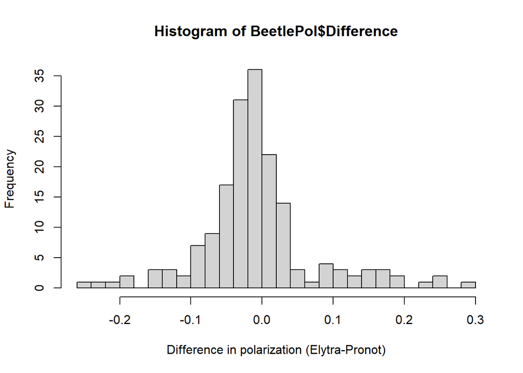

```r
hist(BeetlePol$Difference,
    breaks = 20,
    xlab = "Difference in polarization (Elytra-Pronot)",
    ylab = "Frequency"
)
```

These beetles with higher polarisation in their elytra are:

```r
ElytraMoreP <-
    BeetlePol %>%
    dplyr::filter(Difference > 0.1)

ElytraMoreP$ind
```

```
##  [1] "atki01" "atki02" "brun01" "brun04" "brun05" "ecry01" "fchi01" "fchi02" "hirs03" "lats01" "lats03" "pvul02" "pvul03" "pvul04" "rayn01" "rayn03" "smgr01"
```

These beetles with higher polarisation in their pronotum are:

```r
PronotumMoreP <-
    BeetlePol %>%
    dplyr::filter(Difference < -0.1)

PronotumMoreP$ind
```

```
##  [1] "aurs01" "aurs02" "clor09" "meli02" "meli03" "neus01" "oliv03" "opal01" "pvul01" "rubi01" "rubi02" "vrdi01" "vrdi03"
```

# Climate

**Question**

**Is polarization correlated to the extracted climate variables?**

**Statistics**

## Pagel’s lambda

```r
pagelPDPol <- PolPCsRows$Pol # Define which trait we want to test
names(pagelPDPol) <- rownames(PolPCsRows) # Row names = tree tips
phylosig(MCCtree, pagelPDPol, method = "lambda", test = TRUE, nsim = 999)
```

```
##
## Phylogenetic signal lambda : 0.955198
## logL(lambda) : 40.0202
## LR(lambda=0) : 28.1436
## P-value (based on LR test) : 0.000000112637
```

```r
# nsim = 999 means testing with 999 randomisations
```

Phylogenetic signal is high.

## PGLS in the MCC

Create the data frame of comparative data

```r
# extract sizes
SizesDf <- PolRefl %>%
              dplyr::select("phylogeny_name", "size")
# merge size into ecological variables dataset
PolPCsWithSizes <- merge(SizesDf, PolPCs)

comp_data2 <- comparative.data(
    phy = MCCtree,
    data = PolPCsWithSizes, # aggregated data without the spp in the row names
    names.col = "phylogeny_name", # contains the column phylogeny name
    vcv = TRUE,
    na.omit = FALSE, warn.dropped = TRUE
)
```

Establish the model

```r
pglsPDPol <- pgls(Pol ~ PC1 + PC2 + size + PC1 * size + PC2 * size,
    data = comp_data2, param.CI = 0.95, lambda = "ML"
)

summary(pglsPDPol)
```

```
##
## Call:
## pgls(formula = Pol ~ PC1 + PC2 + size + PC1 * size + PC2 * size,
##     data = comp_data2, lambda = "ML", param.CI = 0.95)
##
## Residuals:
##       Min        1Q    Median        3Q       Max
## -0.073617 -0.016438 -0.005165  0.018150  0.076266
##
## Branch length transformations:
##
## kappa  [Fix]  : 1.000
## lambda [ ML]  : 0.908
##    lower bound : 0.000, p = 0.0000078697
##    upper bound : 1.000, p = 0.0037317
##    95.0% CI   : (0.710, 0.983)
## delta  [Fix]  : 1.000
##
## Coefficients:
##               Estimate Std. Error t value Pr(>|t|)
## (Intercept)  0.0245801  0.1416766  0.1735   0.8631
## PC1         -0.0037788  0.0508632 -0.0743   0.9411
## PC2         -0.1073466  0.0641932 -1.6722   0.1021
## size         0.0107276  0.0493041  0.2176   0.8288
## PC1:size    -0.0078721  0.0218726 -0.3599   0.7208
## PC2:size     0.0358297  0.0257598  1.3909   0.1718
##
## Residual standard error: 0.03551 on 41 degrees of freedom
## Multiple R-squared: 0.2871,  Adjusted R-squared: 0.2001
## F-statistic: 3.302 on 5 and 41 DF,  p-value: 0.01348
```

**Conclusion**

**Polarization does not directly correlate with these ecological variables**

## PGLS in multiple trees

Function

Note that the function has to be modified for the predictors and data frame that we are using

```r
source(here::here("Scripts/7_multiple_pgls_function_B.R")) # script B is for Polarization as a response
```

Model

```r
MuPGLSPol2 <- Polarization ~ PC1 + PC2 + size + PC1 * size + PC2 * size
```

Dataset

```r
# Add the phylogeny name again because in this function it is needed:
PDPol2 <-
    PolPCsWithSizes %>%
    dplyr::select(phylogeny_name, Pol, size, PC1, PC2) %>%
    dplyr::rename("Polarization" = Pol)

PDPol2 <- as.data.frame(PDPol2)
rownames(PDPol2) <- PDPol2[, 1]
```

Apply

```r
runsPol2 <- lapply(trees[trees_subset_min:trees_subset_max],
                   pgls_runB, model = MuPGLSPol2, dataset = PDPol2)
```

[output not shown]

```r
dfPol2 <- ldply(runsPol2, data.frame)
```

Get results

```r
HPDinterval(as.mcmc(dfPol2))
```

```
##                   lower        upper
## estimateP1 -0.019961932  0.012065708
## ts1        -0.398236915  0.218698747
## ps1         0.731524167  0.999803405
## estimateP2 -0.150983585 -0.075873842
## tP2        -2.341620113 -1.284685625
## pP2         0.017177465  0.173785078
## estimateP3 -0.004033164  0.037508114
## tP3        -0.081294101  0.739204491
## pP3         0.472676043  0.999673203
## estimateP4 -0.014311118 -0.001079027
## tP4        -0.659690073 -0.050508450
## pP4         0.513141587  0.939636609
## estimateP5  0.024501773  0.053619651
## tP5         0.974480549  2.027298118
## pP5         0.035180472  0.282547057
## attr(,"Probability")
## [1] 0.950455
```

# Optical properties

## Pol Degree

This is an indication of “how much of the colour is circularly polarised to the left”. As a simplification, we assume that this is equivalent to most of the reflections produced by a chiral mechanism

### Reflectivity

#### VIS

**Question**

**Can polarisation predict visible reflectivity?**

**Correlation**

```r
cor.test(PolRefl$VIS, PolRefl$Pol) # by spp
```

```
##
##  Pearson's product-moment correlation
##
## data:  PolRefl$VIS and PolRefl$Pol
## t = 1.5434, df = 45, p-value = 0.1297
## alternative hypothesis: true correlation is not equal to 0
## 95 percent confidence interval:
##  -0.06728212  0.48044869
## sample estimates:
##       cor
## 0.2242168
```

**Linear model**

```r
ModL1 <- lm(PolRefl$VIS ~ PolRefl$Pol) # by spp
summary(ModL1)
```

```
##
## Call:
## lm(formula = PolRefl$VIS ~ PolRefl$Pol)
##
## Residuals:
##      Min       1Q   Median       3Q      Max
## -10.4480  -4.9439   0.6226   3.3241  18.8607
##
## Coefficients:
##             Estimate Std. Error t value            Pr(>|t|)
## (Intercept)   13.288      1.131  11.744 0.00000000000000268 ***
## PolRefl$Pol   10.617      6.879   1.543                0.13
## ---
## Signif. codes:  0 '***' 0.001 '**' 0.01 '*' 0.05 '.' 0.1 ' ' 1
##
## Residual standard error: 6.57 on 45 degrees of freedom
## Multiple R-squared:  0.05027,    Adjusted R-squared:  0.02917
## F-statistic: 2.382 on 1 and 45 DF,  p-value: 0.1297
```

**PGLS**

Create the data frame of comparative data

```r
comp_data <- comparative.data(
  phy = MCCtree,
  data = PolRefl, # aggregated data without the spp in the row names
  names.col = "phylogeny_name", # contains the column phylogeny name
  vcv = TRUE,
  na.omit = FALSE, warn.dropped = TRUE
)
```

Establish the model

```r
pglsPDVIS <- pgls(VIS ~ Pol,
  data = comp_data, param.CI = 0.95, lambda = "ML"
)

summary(pglsPDVIS)
```

```
##
## Call:
## pgls(formula = VIS ~ Pol, data = comp_data, lambda = "ML", param.CI = 0.95)
##
## Residuals:
##    Min     1Q Median     3Q    Max
## -3.463 -1.473  0.033  1.128  6.399
##
## Branch length transformations:
##
## kappa  [Fix]  : 1.000
## lambda [ ML]  : 0.821
##    lower bound : 0.000, p = 0.59187
##    upper bound : 1.000, p = 0.15519
##    95.0% CI   : (NA, NA)
## delta  [Fix]  : 1.000
##
## Coefficients:
##             Estimate Std. Error t value Pr(>|t|)
## (Intercept)  11.4628     5.1935  2.2072  0.03245 *
## Pol           8.5383     8.8468  0.9651  0.33964
## ---
## Signif. codes:  0 '***' 0.001 '**' 0.01 '*' 0.05 '.' 0.1 ' ' 1
##
## Residual standard error: 2.204 on 45 degrees of freedom
## Multiple R-squared: 0.02028, Adjusted R-squared: -0.001492
## F-statistic: 0.9315 on 1 and 45 DF,  p-value: 0.3396
```

**PGLS multiple trees**

Function

Note that the function has to be modified for the predictors and data frame that we are using

```r
source(here::here("Scripts/6_multiple_pgls_function_A.R")) # script A is for Polarization as a response
```

Model

```r
MuPGLSPol3 <- Response ~ Pol
```

Dataset

```r
PolRefl3 <-
    PolReflRows %>% # phylogeny names in rows
    dplyr::select(Pol, VIS) %>%
    dplyr::rename("Response" = VIS)

PolRefl3 <- as.data.frame(PolRefl3)
```

Apply

```r
runsPol3 <- lapply(trees[trees_subset_min:trees_subset_max],
                   pgls_runA, model = MuPGLSPol3, dataset = PolRefl3)
```

[output not shown]

```r
dfPol3 <- ldply(runsPol3, data.frame)

length(dfPol3[,1])
```

```
## [1] 980
```

Get results

```r
HPDinterval(as.mcmc(dfPol3))
```

```
##                lower      upper
## estimateP1 1.5389948 12.2133812
## ts1        0.2060000  1.5457472
## ps1        0.1200562  0.8031361
## attr(,"Probability")
## [1] 0.95
```

**Conclusion**

**There’s no correlation between visible reflectivity and polarisation at the species level.**

#### NIR

**Question**

**Is polarisation correlated with NIR reflectivity?**

**Correlation**

Species level:

```r
cor.test(PolRefl$NIR, PolRefl$Pol) # by spp
```

```
##
##  Pearson's product-moment correlation
##
## data:  PolRefl$NIR and PolRefl$Pol
## t = -1.7419, df = 45, p-value = 0.08836
## alternative hypothesis: true correlation is not equal to 0
## 95 percent confidence interval:
##  -0.50225033  0.03862105
## sample estimates:
##        cor
## -0.2513332
```

**Linear model**

```r
ModL2 <- lm(PolRefl$NIR ~ PolRefl$Pol + PolRefl$VIS) # by spp
summary(ModL2)
```

```
##
## Call:
## lm(formula = PolRefl$NIR ~ PolRefl$Pol + PolRefl$VIS)
##
## Residuals:
##      Min       1Q   Median       3Q      Max
## -10.7760  -3.7231   0.3623   1.8078  26.2201
##
## Coefficients:
##             Estimate Std. Error t value            Pr(>|t|)
## (Intercept)  26.4224     2.2774  11.602 0.00000000000000563 ***
## PolRefl$Pol -29.5900     7.0475  -4.199            0.000129 ***
## PolRefl$VIS   1.1102     0.1488   7.460 0.00000000243789919 ***
## ---
## Signif. codes:  0 '***' 0.001 '**' 0.01 '*' 0.05 '.' 0.1 ' ' 1
##
## Residual standard error: 6.56 on 44 degrees of freedom
## Multiple R-squared:  0.5863, Adjusted R-squared:  0.5675
## F-statistic: 31.18 on 2 and 44 DF,  p-value: 0.000000003685
```

**PGLS**

The data frame of comparative data is the same as for visible light

```r
pglsPDNIR <- pgls(NIR ~ Pol + VIS,
  data = comp_data, param.CI = 0.95, lambda = "ML"
)

summary(pglsPDNIR)
```

```
##
## Call:
## pgls(formula = NIR ~ Pol + VIS, data = comp_data, lambda = "ML",
##     param.CI = 0.95)
##
## Residuals:
##     Min      1Q  Median      3Q     Max
## -3.3801 -1.0779 -0.2568  0.5219  7.7747
##
## Branch length transformations:
##
## kappa  [Fix]  : 1.000
## lambda [ ML]  : 0.602
##    lower bound : 0.000, p = 0.34197
##    upper bound : 1.000, p = 0.021873
##    95.0% CI   : (NA, 0.985)
## delta  [Fix]  : 1.000
##
## Coefficients:
##             Estimate Std. Error t value       Pr(>|t|)
## (Intercept)  30.4608     4.3375  7.0227 0.000000010590 ***
## Pol         -28.4643     8.2204 -3.4627       0.001203 **
## VIS           1.1146     0.1471  7.5774 0.000000001644 ***
## ---
## Signif. codes:  0 '***' 0.001 '**' 0.01 '*' 0.05 '.' 0.1 ' ' 1
##
## Residual standard error: 1.824 on 44 degrees of freedom
## Multiple R-squared: 0.5847,  Adjusted R-squared: 0.5658
## F-statistic: 30.97 on 2 and 44 DF,  p-value: 0.000000004027
```

**PGLS multiple trees**

Function

Note that the function has to be modified for the predictors and data frame that we are using

```r
source(here::here("Scripts/13_multiple_pgls_function_H.R")) # script A is for Polarization as a predictor
```

Model

```r
MuPGLSPol4 <- Response ~ Pol + VIS
```

Dataset

```r
PolRefl4 <-
    PolReflRows %>% # phylogeny names in rows
    dplyr::select(Pol, VIS, NIR) %>%
    dplyr::rename("Response" = NIR)

PolRefl4 <- as.data.frame(PolRefl4)
```

Apply

```r
runsPol4 <- lapply(trees[trees_subset_min:trees_subset_max],
                   pgls_runH, model = MuPGLSPol4, dataset = PolRefl4)

dfPol4 <- ldply(runsPol4, data.frame)

length(dfPol4[,1])
```

```
## [1] 1001
```

Get results

```r
HPDinterval(as.mcmc(dfPol4))
```

```
##                           lower               upper
## estimateP1 -30.5787807936124665 -26.984834060583118
## ts1         -4.1986326287349671  -3.208252902704267
## ps1          0.0001285882928512   0.002492216158802
## estimateP2   1.0936560546755665   1.133847417482905
## tP2          7.3334922240313078   7.843723842514416
## pP2          0.0000000006540746   0.000000003672992
## attr(,"Probability")
## [1] 0.95005
```

#### FRS

**Question**

**Is polarisation correlated with the NIR residuals corrected by phylogeny?**

**Correlation**

Species level:

```r
cor.test(PolRefl$FRS, PolRefl$Pol) # by spp
```

```
##
##  Pearson's product-moment correlation
##
## data:  PolRefl$FRS and PolRefl$Pol
## t = -4.2698, df = 45, p-value = 0.00009974
## alternative hypothesis: true correlation is not equal to 0
## 95 percent confidence interval:
##  -0.7140250 -0.2953307
## sample estimates:
##        cor
## -0.5369585
```

**Linear model**

```r
ModL3 <- lm(PolRefl$FRS ~ PolRefl$Pol) # by spp
summary(ModL3)
```

```
##
## Call:
## lm(formula = PolRefl$FRS ~ PolRefl$Pol)
##
## Residuals:
##      Min       1Q   Median       3Q      Max
## -10.7187  -3.4801   0.3577   2.0168  26.3987
##
## Coefficients:
##             Estimate Std. Error t value  Pr(>|t|)
## (Intercept)   -3.270      1.119  -2.924   0.00539 **
## PolRefl$Pol  -29.038      6.801  -4.270 0.0000997 ***
## ---
## Signif. codes:  0 '***' 0.001 '**' 0.01 '*' 0.05 '.' 0.1 ' ' 1
##
## Residual standard error: 6.495 on 45 degrees of freedom
## Multiple R-squared:  0.2883, Adjusted R-squared:  0.2725
## F-statistic: 18.23 on 1 and 45 DF,  p-value: 0.00009974
```

**PGLS**

The data frame of comparative data is the same as for visible light

```r
pglsPDFRS <- pgls(FRS ~ Pol,
  data = comp_data, param.CI = 0.95, lambda = "ML"
)

summary(pglsPDFRS)
```

```
##
## Call:
## pgls(formula = FRS ~ Pol, data = comp_data, lambda = "ML", param.CI = 0.95)
##
## Residuals:
##     Min      1Q  Median      3Q     Max
## -3.3650 -1.0477 -0.2635  0.5654  7.8514
##
## Branch length transformations:
##
## kappa  [Fix]  : 1.000
## lambda [ ML]  : 0.603
##    lower bound : 0.000, p = 0.34922
##    upper bound : 1.000, p = 0.023464
##    95.0% CI   : (NA, 0.986)
## delta  [Fix]  : 1.000
##
## Coefficients:
##              Estimate Std. Error t value Pr(>|t|)
## (Intercept)   0.74353    3.95005  0.1882 0.851541
## Pol         -27.88818    8.01185 -3.4809 0.001123 **
## ---
## Signif. codes:  0 '***' 0.001 '**' 0.01 '*' 0.05 '.' 0.1 ' ' 1
##
## Residual standard error: 1.809 on 45 degrees of freedom
## Multiple R-squared: 0.2121,  Adjusted R-squared: 0.1946
## F-statistic: 12.12 on 1 and 45 DF,  p-value: 0.001123
```

**PGLS multiple trees**

Dataset

```r
PolRefl5 <-
    PolReflRows %>% # phylogeny names in rows
    dplyr::select(Pol, FRS) %>%
    dplyr::rename("Response" = FRS)

PolRefl5 <- as.data.frame(PolRefl5)
```

Apply

```r
runsPol5 <- lapply(trees[trees_subset_min:trees_subset_max],
                   pgls_runA, model = MuPGLSPol3, dataset = PolRefl5)

dfPol5 <- ldply(runsPol5, data.frame)

length(dfPol5[,1])
```

```
## [1] 1001
```

Get results

```r
HPDinterval(as.mcmc(dfPol5))
```

```
##                      lower         upper
## estimateP1 -29.78511659011 -26.361994828
## ts1         -4.26978422766  -3.205786973
## ps1          0.00009973628   0.002479313
## attr(,"Probability")
## [1] 0.95005
```

### Absorptivity

#### VIS

**Question**

**Can polarisation predict visible absorptivity?**

**Correlation**

```r
cor.test(PolAbs$VIS, PolAbs$Pol) # by spp
```

```
##
##  Pearson's product-moment correlation
##
## data:  PolAbs$VIS and PolAbs$Pol
## t = 0.041288, df = 24, p-value = 0.9674
## alternative hypothesis: true correlation is not equal to 0
## 95 percent confidence interval:
##  -0.3801654  0.3944917
## sample estimates:
##         cor
## 0.008427517
```

**Linear model**

```r
ModL1Abs <- lm(PolAbs$VIS ~ PolAbs$Pol) # by spp
summary(ModL1Abs)
```

```
##
## Call:
## lm(formula = PolAbs$VIS ~ PolAbs$Pol)
##
## Residuals:
##      Min       1Q   Median       3Q      Max
## -23.4765  -4.4632   0.5597   7.5187  14.9412
##
## Coefficients:
##             Estimate Std. Error t value            Pr(>|t|)
## (Intercept)  79.3015     2.3443  33.828 <0.0000000000000002 ***
## PolAbs$Pol    0.5093    12.3345   0.041               0.967
## ---
## Signif. codes:  0 '***' 0.001 '**' 0.01 '*' 0.05 '.' 0.1 ' ' 1
##
## Residual standard error: 9.99 on 24 degrees of freedom
## Multiple R-squared:  7.102e-05,  Adjusted R-squared:  -0.04159
## F-statistic: 0.001705 on 1 and 24 DF,  p-value: 0.9674
```

**PGLS**

Create the data frame of comparative data

```r
CompDataAbs <- comparative.data(
  phy = MCCtreeAbs,
  data = PolAbs, # aggregated data without the spp in the row names
  names.col = "phylogeny_name", # contains the column phylogeny name
  vcv = TRUE,
  na.omit = FALSE, warn.dropped = TRUE
)
```

Establish the model

```r
pglsPDVISAbs <- pgls(VIS ~ Pol,
  data = CompDataAbs, param.CI = 0.95, lambda = "ML"
)

summary(pglsPDVISAbs)
```

```
##
## Call:
## pgls(formula = VIS ~ Pol, data = CompDataAbs, lambda = "ML",
##     param.CI = 0.95)
##
## Residuals:
##     Min      1Q  Median      3Q     Max
## -8.0851 -1.5359  0.0797  2.6208  6.0661
##
## Branch length transformations:
##
## kappa  [Fix]  : 1.000
## lambda [ ML]  : 0.969
##    lower bound : 0.000, p = 0.29867
##    upper bound : 1.000, p = 0.4437
##    95.0% CI   : (NA, NA)
## delta  [Fix]  : 1.000
##
## Coefficients:
##             Estimate Std. Error t value       Pr(>|t|)
## (Intercept)  80.7282     9.2640  8.7142 0.000000006724 ***
## Pol           5.9897    15.8311  0.3784         0.7085
## ---
## Signif. codes:  0 '***' 0.001 '**' 0.01 '*' 0.05 '.' 0.1 ' ' 1
##
## Residual standard error: 3.695 on 24 degrees of freedom
## Multiple R-squared: 0.005929,    Adjusted R-squared: -0.03549
## F-statistic: 0.1432 on 1 and 24 DF,  p-value: 0.7085
```

**PGLS multiple trees**

Dataset

```r
PolAbs3 <-
    PolAbsRows %>% # phylogeny names in rows
    dplyr::select(Pol, VIS) %>%
    dplyr::rename("Response" = VIS)

PolAbs3 <- as.data.frame(PolAbs3)
```

Apply

```r
runsPol6 <- lapply(trees[trees_subset_min:trees_subset_max],
                   pgls_runA, model = MuPGLSPol3, dataset = PolAbs3)
```

[output not shown]

```r
dfPol6 <- ldply(runsPol6, data.frame)

length(dfPol6[,1])
```

```
## [1] 963
```

Get results

```r
HPDinterval(as.mcmc(dfPol6))
```

```
##                 lower      upper
## estimateP1 0.45439180 11.9958349
## ts1        0.04128687  0.8167620
## ps1        0.43312728  0.9674088
## attr(,"Probability")
## [1] 0.9501558
```

**Conclusion**

**There’s no correlation between visible absorptivity and polarisation at the species level.**

#### NIR

**Question**

**Is polarisation correlated with NIR absorptivity?**

**Correlation**

Species level:

```r
cor.test(PolAbs$NIR, PolAbs$Pol) # by spp
```

```
##
##  Pearson's product-moment correlation
##
## data:  PolAbs$NIR and PolAbs$Pol
## t = 1.0748, df = 24, p-value = 0.2932
## alternative hypothesis: true correlation is not equal to 0
## 95 percent confidence interval:
##  -0.1887276  0.5555297
## sample estimates:
##       cor
## 0.2142898
```

**Linear model**

```r
ModL2Abs <- lm(PolAbs$NIR ~ PolAbs$Pol + PolAbs$VIS) # by spp
summary(ModL2Abs)
```

```
##
## Call:
## lm(formula = PolAbs$NIR ~ PolAbs$Pol + PolAbs$VIS)
##
## Residuals:
##      Min       1Q   Median       3Q      Max
## -14.1275  -4.5971   0.2726   4.3498  11.4918
##
## Coefficients:
##             Estimate Std. Error t value      Pr(>|t|)
## (Intercept)  -73.006     11.617  -6.285 0.00000206065 ***
## PolAbs$Pol    19.381      8.761   2.212        0.0372 *
## PolAbs$VIS     1.345      0.145   9.274 0.00000000311 ***
## ---
## Signif. codes:  0 '***' 0.001 '**' 0.01 '*' 0.05 '.' 0.1 ' ' 1
##
## Residual standard error: 7.095 on 23 degrees of freedom
## Multiple R-squared:  0.7987, Adjusted R-squared:  0.7812
## F-statistic: 45.62 on 2 and 23 DF,  p-value: 0.000000009877
```

**PGLS**

The data frame of comparative data is the same as for visible light

```r
pglsPDNIRAbs <- pgls(NIR ~ Pol + VIS,
  data = CompDataAbs, param.CI = 0.95, lambda = "ML"
)

summary(pglsPDNIRAbs)
```

```
##
## Call:
## pgls(formula = NIR ~ Pol + VIS, data = CompDataAbs, lambda = "ML",
##     param.CI = 0.95)
##
## Residuals:
##     Min      1Q  Median      3Q     Max
## -3.6008 -0.9192  0.5430  1.3462  3.6475
##
## Branch length transformations:
##
## kappa  [Fix]  : 1.000
## lambda [ ML]  : 0.698
##    lower bound : 0.000, p = 0.047281
##    upper bound : 1.000, p = 0.09444
##    95.0% CI   : (0.024, NA)
## delta  [Fix]  : 1.000
##
## Coefficients:
##              Estimate Std. Error t value        Pr(>|t|)
## (Intercept) -79.24713   11.51810 -6.8802 0.0000005146022 ***
## Pol          18.59591    9.55406  1.9464         0.06392 .
## VIS           1.34625    0.13193 10.2041 0.0000000005214 ***
## ---
## Signif. codes:  0 '***' 0.001 '**' 0.01 '*' 0.05 '.' 0.1 ' ' 1
##
## Residual standard error: 1.878 on 23 degrees of freedom
## Multiple R-squared: 0.8256,  Adjusted R-squared: 0.8104
## F-statistic: 54.42 on 2 and 23 DF,  p-value: 0.000000001902
```

**PGLS multiple trees**

Dataset

```r
PolAbs4 <-
    PolAbsRows %>% # phylogeny names in rows
    dplyr::select(Pol, VIS, NIR) %>%
    dplyr::rename("Response" = NIR)

PolAbs4 <- as.data.frame(PolAbs4)
```

Apply

```r
runsPol7 <- lapply(trees[trees_subset_min:trees_subset_max],
                   pgls_runH, model = MuPGLSPol4, dataset = PolAbs4)

dfPol7 <- ldply(runsPol7, data.frame)

length(dfPol7[,1])
```

```
## [1] 1001
```

Get results

```r
HPDinterval(as.mcmc(dfPol7))
```

```
##                          lower              upper
## estimateP1 17.1499526859974480 21.154935391163267
## ts1         1.8199538150269474  2.345445447530623
## ps1         0.0263609336822412  0.079977595961537
## estimateP2  1.3184074324238098  1.360615900689254
## tP2         9.6488193841426106 10.803000242408297
## pP2         0.0000000001229536  0.000000001323613
## attr(,"Probability")
## [1] 0.95005
```

#### FRS

**Question**

**Is polarisation correlated with the NIR residuals corrected by phylogeny?**

**Correlation**

Species level:

```r
cor.test(PolAbs$FRS, PolAbs$Pol) # by spp
```

```
##
##  Pearson's product-moment correlation
##
## data:  PolAbs$FRS and PolAbs$Pol
## t = 2.2597, df = 24, p-value = 0.03319
## alternative hypothesis: true correlation is not equal to 0
## 95 percent confidence interval:
##  0.03759808 0.69366079
## sample estimates:
##     cor
## 0.41885
```

**Linear model**

```r
ModL3Abs <- lm(PolAbs$FRS ~ PolAbs$Pol) # by spp
summary(ModL3Abs)
```

```
##
## Call:
## lm(formula = PolAbs$FRS ~ PolAbs$Pol)
##
## Residuals:
##      Min       1Q   Median       3Q      Max
## -14.1317  -4.5898   0.3022   4.3367  11.4591
##
## Coefficients:
##             Estimate Std. Error t value Pr(>|t|)
## (Intercept)    5.061      1.630   3.105  0.00483 **
## PolAbs$Pol    19.379      8.576   2.260  0.03319 *
## ---
## Signif. codes:  0 '***' 0.001 '**' 0.01 '*' 0.05 '.' 0.1 ' ' 1
##
## Residual standard error: 6.946 on 24 degrees of freedom
## Multiple R-squared:  0.1754, Adjusted R-squared:  0.1411
## F-statistic: 5.106 on 1 and 24 DF,  p-value: 0.03319
```

**PGLS**

The data frame of comparative data is the same as for visible light

```r
pglsPDFRSAbs <- pgls(FRS ~ Pol,
  data = CompDataAbs, param.CI = 0.95, lambda = "ML"
)

summary(pglsPDFRSAbs)
```

```
##
## Call:
## pgls(formula = FRS ~ Pol, data = CompDataAbs, lambda = "ML",
##     param.CI = 0.95)
##
## Residuals:
##     Min      1Q  Median      3Q     Max
## -3.6041 -0.9185  0.5429  1.3454  3.6435
##
## Branch length transformations:
##
## kappa  [Fix]  : 1.000
## lambda [ ML]  : 0.697
##    lower bound : 0.000, p = 0.047271
##    upper bound : 1.000, p = 0.087831
##    95.0% CI   : (0.024, NA)
## delta  [Fix]  : 1.000
##
## Coefficients:
##             Estimate Std. Error t value Pr(>|t|)
## (Intercept)  -1.0393     4.2966 -0.2419  0.81092
## Pol          18.5950     9.3502  1.9887  0.05825 .
## ---
## Signif. codes:  0 '***' 0.001 '**' 0.01 '*' 0.05 '.' 0.1 ' ' 1
##
## Residual standard error: 1.839 on 24 degrees of freedom
## Multiple R-squared: 0.1415,  Adjusted R-squared: 0.1057
## F-statistic: 3.955 on 1 and 24 DF,  p-value: 0.05825
```

**PGLS multiple trees**

Dataset

```r
PolAbs5 <-
    PolAbsRows %>% # phylogeny names in rows
    dplyr::select(Pol, FRS) %>%
    dplyr::rename("Response" = FRS)

PolAbs5 <- as.data.frame(PolAbs5)
```

Apply

```r
runsPol8 <- lapply(trees[trees_subset_min:trees_subset_max],
                   pgls_runA, model = MuPGLSPol3, dataset = PolAbs5)

dfPol8 <- ldply(runsPol8, data.frame)

length(dfPol8[,1])
```

```
## [1] 1001
```

Get results

```r
HPDinterval(as.mcmc(dfPol8))
```

```
##                  lower       upper
## estimateP1 17.15984924 21.18197601
## ts1         1.85696827  2.39465696
## ps1         0.02383071  0.07389166
## attr(,"Probability")
## [1] 0.95005
```

## Right handed Pol

### Reflectivity

#### VIS

**Question**

**Can the darkness in the underlaying pigment affect the visible reflectivity?**

**Correlation**

```r
cor.test(RHandRefl$VIS, RHandRefl$Pol) # by spp
```

```
##
##  Pearson's product-moment correlation
##
## data:  RHandRefl$VIS and RHandRefl$Pol
## t = 4.5919, df = 45, p-value = 0.00003531
## alternative hypothesis: true correlation is not equal to 0
## 95 percent confidence interval:
##  0.3314552 0.7331079
## sample estimates:
##       cor
## 0.5648573
```

**Linear model**

```r
ModL1RH <- lm(RHandRefl$VIS ~ RHandRefl$Pol) # by spp
summary(ModL1RH)
```

```
##
## Call:
## lm(formula = RHandRefl$VIS ~ RHandRefl$Pol)
##
## Residuals:
##    Min     1Q Median     3Q    Max
## -7.183 -3.552 -1.193  1.611 21.904
##
## Coefficients:
##               Estimate Std. Error t value  Pr(>|t|)
## (Intercept)     3.0506     2.5633   1.190      0.24
## RHandRefl$Pol   2.4853     0.5412   4.592 0.0000353 ***
## ---
## Signif. codes:  0 '***' 0.001 '**' 0.01 '*' 0.05 '.' 0.1 ' ' 1
##
## Residual standard error: 5.563 on 45 degrees of freedom
## Multiple R-squared:  0.3191, Adjusted R-squared:  0.3039
## F-statistic: 21.09 on 1 and 45 DF,  p-value: 0.00003531
```

**PGLS**

Create the data frame of comparative data

```r
comp_dataRH <- comparative.data(
  phy = MCCtree,
  data = RHandRefl, # aggregated data without the spp in the row names
  names.col = "phylogeny_name", # contains the column phylogeny name
  vcv = TRUE,
  na.omit = FALSE, warn.dropped = TRUE
)
```

Establish the model

```r
pglsPDVISRH <- pgls(VIS ~ Pol,
  data = comp_dataRH, param.CI = 0.95, lambda = "ML"
)

summary(pglsPDVISRH)
```

```
##
## Call:
## pgls(formula = VIS ~ Pol, data = comp_dataRH, lambda = "ML",
##     param.CI = 0.95)
##
## Residuals:
##     Min      1Q  Median      3Q     Max
## -2.7136 -1.4749 -0.2582  0.7616  7.7002
##
## Branch length transformations:
##
## kappa  [Fix]  : 1.000
## lambda [ ML]  : 0.944
##    lower bound : 0.000, p = 0.0018141
##    upper bound : 1.000, p = 0.10278
##    95.0% CI   : (0.699, NA)
## delta  [Fix]  : 1.000
##
## Coefficients:
##             Estimate Std. Error t value     Pr(>|t|)
## (Intercept)  2.71490    5.10664  0.5316       0.5976
## Pol          2.48798    0.42974  5.7896 0.0000006404 ***
## ---
## Signif. codes:  0 '***' 0.001 '**' 0.01 '*' 0.05 '.' 0.1 ' ' 1
##
## Residual standard error: 2.007 on 45 degrees of freedom
## Multiple R-squared: 0.4269,  Adjusted R-squared: 0.4142
## F-statistic: 33.52 on 1 and 45 DF,  p-value: 0.0000006404
```

**PGLS multiple trees**

Function

Note that the function has to be modified for the predictors and data frame that we are using

```r
source(here::here("Scripts/6_multiple_pgls_function_A.R")) # script A is for Polarization as a response
```

Model

```r
MuPGLSPol3 <- Response ~ Pol
```

Dataset

```r
RHandRefl3 <-
    RHandReflRows %>% # phylogeny names in rows
    dplyr::select(Pol, VIS) %>%
    dplyr::rename("Response" = VIS)

RHandRefl3 <- as.data.frame(RHandRefl3)
```

Apply

```r
runsRHPol3 <- lapply(trees[trees_subset_min:trees_subset_max],
                   pgls_runA, model = MuPGLSPol3, dataset = RHandRefl3)
```

[output not shown]

```r
dfRHPol3 <- ldply(runsRHPol3, data.frame)

length(dfRHPol3[,1])
```

```
## [1] 992
```

Get results

```r
HPDinterval(as.mcmc(dfRHPol3))
```

```
##                       lower          upper
## estimateP1 2.32471130950857 2.675270900988
## ts1        5.32476946879407 6.392733318809
## ps1        0.00000001819721 0.000002109167
## attr(,"Probability")
## [1] 0.9495968
```

#### NIR

**Question**

**Can the darkness in the underlaying pigment affect the NIR reflectivity?**

**Correlation**

Species level:

```r
cor.test(RHandRefl$NIR, RHandRefl$Pol) # by spp
```

```
##
##  Pearson's product-moment correlation
##
## data:  RHandRefl$NIR and RHandRefl$Pol
## t = 4.8707, df = 45, p-value = 0.00001413
## alternative hypothesis: true correlation is not equal to 0
## 95 percent confidence interval:
##  0.3613412 0.7484313
## sample estimates:
##       cor
## 0.5875417
```

**Linear model**

```r
ModL2RH <- lm(RHandRefl$NIR ~ RHandRefl$Pol + RHandRefl$VIS) # by spp
summary(ModL2RH)
```

```
##
## Call:
## lm(formula = RHandRefl$NIR ~ RHandRefl$Pol + RHandRefl$VIS)
##
## Residuals:
##     Min      1Q  Median      3Q     Max
## -9.9226 -4.3421 -0.2965  2.4271 24.2257
##
## Coefficients:
##               Estimate Std. Error t value    Pr(>|t|)
## (Intercept)    20.1240     3.4000   5.919 0.000000444 ***
## RHandRefl$Pol   2.1381     0.8566   2.496    0.016379 *
## RHandRefl$VIS   0.6956     0.1947   3.573    0.000871 ***
## ---
## Signif. codes:  0 '***' 0.001 '**' 0.01 '*' 0.05 '.' 0.1 ' ' 1
##
## Residual standard error: 7.266 on 44 degrees of freedom
## Multiple R-squared:  0.4925, Adjusted R-squared:  0.4694
## F-statistic: 21.35 on 2 and 44 DF,  p-value: 0.0000003315
```

**PGLS**

The data frame of comparative data is the same as for visible light

```r
pglsPDNIRRH <- pgls(NIR ~ Pol + VIS,
  data = comp_dataRH, param.CI = 0.95, lambda = "ML"
)

summary(pglsPDNIRRH)
```

```
##
## Call:
## pgls(formula = NIR ~ Pol + VIS, data = comp_dataRH, lambda = "ML",
##     param.CI = 0.95)
##
## Residuals:
##     Min      1Q  Median      3Q     Max
## -3.6004 -1.8025 -0.3117  0.8898  8.8684
##
## Branch length transformations:
##
## kappa  [Fix]  : 1.000
## lambda [ ML]  : 0.827
##    lower bound : 0.000, p = 0.00854
##    upper bound : 1.000, p = 0.10273
##    95.0% CI   : (0.340, NA)
## delta  [Fix]  : 1.000
##
## Coefficients:
##             Estimate Std. Error t value   Pr(>|t|)
## (Intercept) 26.50712    5.84639  4.5339 0.00004418 ***
## Pol          1.97254    0.80127  2.4618  0.0178146 *
## VIS          0.73731    0.19706  3.7416  0.0005261 ***
## ---
## Signif. codes:  0 '***' 0.001 '**' 0.01 '*' 0.05 '.' 0.1 ' ' 1
##
## Residual standard error: 2.286 on 44 degrees of freedom
## Multiple R-squared: 0.548,   Adjusted R-squared: 0.5274
## F-statistic: 26.67 on 2 and 44 DF,  p-value: 0.00000002592
```

**PGLS multiple trees**

Function

Note that the function has to be modified for the predictors and data frame that we are using

```r
source(here::here("Scripts/13_multiple_pgls_function_H.R")) # script A is for Polarization as a response
```

Model

```r
MuPGLSPol4 <- Response ~ Pol + VIS
```

Dataset

```r
RHandRefl4 <-
    RHandReflRows %>% # phylogeny names in rows
    dplyr::select(Pol, VIS, NIR) %>%
    dplyr::rename("Response" = NIR)

RHandRefl4 <- as.data.frame(RHandRefl4)
```

Apply

```r
runsRHPol4 <- lapply(trees[trees_subset_min:trees_subset_max],
                   pgls_runH, model = MuPGLSPol4, dataset = RHandRefl4)

dfRHPol4 <- ldply(runsRHPol4, data.frame)

length(dfRHPol4[,1])
```

```
## [1] 1001
```

Get results

```r
HPDinterval(as.mcmc(dfRHPol4))
```

```
##                     lower       upper
## estimateP1 1.568982596475 2.343066714
## ts1        2.227658400835 2.925192813
## ps1        0.004720836798 0.028982730
## estimateP2 0.662245251570 0.813247260
## tP2        3.317189090327 4.402433444
## pP2        0.000006930049 0.001525176
## attr(,"Probability")
## [1] 0.95005
```

#### FRS

**Question**

**Can the darkness in the underlaying pigment affect the NIR reflectivity?**

**Correlation**

Species level:

```r
cor.test(RHandRefl$FRS, RHandRefl$Pol) # by spp
```

```
##
##  Pearson's product-moment correlation
##
## data:  RHandRefl$FRS and RHandRefl$Pol
## t = 1.7038, df = 45, p-value = 0.09531
## alternative hypothesis: true correlation is not equal to 0
## 95 percent confidence interval:
##  -0.04410901  0.49812836
## sample estimates:
##      cor
## 0.246176
```

**Linear model**

```r
ModL3RH <- lm(RHandRefl$FRS ~ RHandRefl$Pol) # by spp
summary(ModL3RH)
```

```
##
## Call:
## lm(formula = RHandRefl$FRS ~ RHandRefl$Pol)
##
## Residuals:
##      Min       1Q   Median       3Q      Max
## -10.3853  -5.1370  -0.4918   3.1890  26.0037
##
## Coefficients:
##               Estimate Std. Error t value Pr(>|t|)
## (Intercept)    -11.366      3.438  -3.306  0.00187 **
## RHandRefl$Pol    1.237      0.726   1.704  0.09531 .
## ---
## Signif. codes:  0 '***' 0.001 '**' 0.01 '*' 0.05 '.' 0.1 ' ' 1
##
## Residual standard error: 7.462 on 45 degrees of freedom
## Multiple R-squared:  0.0606, Adjusted R-squared:  0.03973
## F-statistic: 2.903 on 1 and 45 DF,  p-value: 0.09531
```

**PGLS**

The data frame of comparative data is the same as for visible light

```r
pglsPDFRSRH <- pgls(FRS ~ Pol,
  data = comp_dataRH, param.CI = 0.95, lambda = "ML"
)

summary(pglsPDFRSRH)
```

```
##
## Call:
## pgls(formula = FRS ~ Pol, data = comp_dataRH, lambda = "ML",
##     param.CI = 0.95)
##
## Residuals:
##     Min      1Q  Median      3Q     Max
## -4.0152 -1.7088 -0.6232  0.9233  9.9783
##
## Branch length transformations:
##
## kappa  [Fix]  : 1.000
## lambda [ ML]  : 0.875
##    lower bound : 0.000, p = 0.005182
##    upper bound : 1.000, p = 0.2351
##    95.0% CI   : (0.400, NA)
## delta  [Fix]  : 1.000
##
## Coefficients:
##             Estimate Std. Error t value Pr(>|t|)
## (Intercept) -4.26850    6.28085 -0.6796  0.50024
## Pol          1.09243    0.61722  1.7699  0.08352 .
## ---
## Signif. codes:  0 '***' 0.001 '**' 0.01 '*' 0.05 '.' 0.1 ' ' 1
##
## Residual standard error: 2.464 on 45 degrees of freedom
## Multiple R-squared: 0.06508, Adjusted R-squared: 0.04431
## F-statistic: 3.133 on 1 and 45 DF,  p-value: 0.08352
```

**PGLS multiple trees**

Dataset

```r
RHandRefl5 <-
    RHandReflRows %>% # phylogeny names in rows
    dplyr::select(Pol, FRS) %>%
    dplyr::rename("Response" = FRS)

RHandRefl5 <- as.data.frame(RHandRefl5)
```

Apply

```r
runsRHPol5 <- lapply(trees[trees_subset_min:trees_subset_max],
                   pgls_runA, model = MuPGLSPol3, dataset = RHandRefl5)

dfRHPol5 <- ldply(runsRHPol5, data.frame)

length(dfRHPol5[,1])
```

```
## [1] 1001
```

Get results

```r
HPDinterval(as.mcmc(dfRHPol5))
```

```
##                 lower     upper
## estimateP1 0.86062030 1.3845539
## ts1        1.50152500 2.3154223
## ps1        0.02085044 0.1321538
## attr(,"Probability")
## [1] 0.95005
```

### Absorptivity

#### VIS

**Question**

**Can polarisation predict visible absorptivity?**

**Correlation**

```r
cor.test(RHandAbs$VIS, RHandAbs$Pol) # by spp
```

```
##
##  Pearson's product-moment correlation
##
## data:  RHandAbs$VIS and RHandAbs$Pol
## t = -0.82271, df = 24, p-value = 0.4188
## alternative hypothesis: true correlation is not equal to 0
## 95 percent confidence interval:
##  -0.5196329  0.2369354
## sample estimates:
##        cor
## -0.1656164
```

**Linear model**

```r
ModL1AbsRH <- lm(RHandAbs$VIS ~ RHandAbs$Pol) # by spp
summary(ModL1AbsRH)
```

```
##
## Call:
## lm(formula = RHandAbs$VIS ~ RHandAbs$Pol)
##
## Residuals:
##      Min       1Q   Median       3Q      Max
## -23.7907  -5.6429   0.3487   7.6899  13.0918
##
## Coefficients:
##              Estimate Std. Error t value          Pr(>|t|)
## (Intercept)    83.909      5.863  14.312 0.000000000000301 ***
## RHandAbs$Pol   -1.110      1.349  -0.823             0.419
## ---
## Signif. codes:  0 '***' 0.001 '**' 0.01 '*' 0.05 '.' 0.1 ' ' 1
##
## Residual standard error: 9.852 on 24 degrees of freedom
## Multiple R-squared:  0.02743,    Adjusted R-squared:  -0.0131
## F-statistic: 0.6769 on 1 and 24 DF,  p-value: 0.4188
```

**PGLS**

Create the data frame of comparative data

```r
CompDataAbsRH <- comparative.data(
  phy = MCCtreeAbs,
  data = RHandAbs, # aggregated data without the spp in the row names
  names.col = "phylogeny_name", # contains the column phylogeny name
  vcv = TRUE,
  na.omit = FALSE, warn.dropped = TRUE
)
```

Establish the model

```r
pglsPDVISAbsRH <- pgls(VIS ~ Pol,
  data = CompDataAbsRH, param.CI = 0.95, lambda = "ML"
)

summary(pglsPDVISAbsRH)
```

```
##
## Call:
## pgls(formula = VIS ~ Pol, data = CompDataAbsRH, lambda = "ML",
##     param.CI = 0.95)
##
## Residuals:
##     Min      1Q  Median      3Q     Max
## -7.9689 -1.5659  0.0845  2.3200  5.5711
##
## Branch length transformations:
##
## kappa  [Fix]  : 1.000
## lambda [ ML]  : 0.958
##    lower bound : 0.000, p = 0.52354
##    upper bound : 1.000, p = 0.34748
##    95.0% CI   : (NA, NA)
## delta  [Fix]  : 1.000
##
## Coefficients:
##             Estimate Std. Error t value     Pr(>|t|)
## (Intercept) 83.17557    9.94708  8.3618 0.0000000143 ***
## Pol         -0.52023    1.18225 -0.4400       0.6638
## ---
## Signif. codes:  0 '***' 0.001 '**' 0.01 '*' 0.05 '.' 0.1 ' ' 1
##
## Residual standard error: 3.619 on 24 degrees of freedom
## Multiple R-squared: 0.008003,    Adjusted R-squared: -0.03333
## F-statistic: 0.1936 on 1 and 24 DF,  p-value: 0.6638
```

**PGLS multiple trees**

Dataset

```r
RHandAbs3 <-
    RHandAbsRows %>% # phylogeny names in rows
    dplyr::select(Pol, VIS) %>%
    dplyr::rename("Response" = VIS)

RHandAbs3 <- as.data.frame(RHandAbs3)
```

Apply

```r
runsRHPol6 <- lapply(trees[trees_subset_min:trees_subset_max],
                   pgls_runA, model = MuPGLSPol3, dataset = RHandAbs3)
```

[output not shown]

```r
dfRHPol6 <- ldply(runsRHPol6, data.frame)

length(dfRHPol6[,1])
```

```
## [1] 971
```

Get results

```r
HPDinterval(as.mcmc(dfRHPol6))
```

```
##                 lower       upper
## estimateP1 -1.1101595 -0.09741585
## ts1        -0.8227129 -0.08824638
## ps1         0.4187710  0.91363493
## attr(,"Probability")
## [1] 0.9495366
```

**Conclusion**

**There’s no correlation between visible absorptivity and polarisation at the species level.**

#### NIR

**Question**

**Is polarisation correlated with NIR absorptivity?**

**Correlation**

Species level:

```r
cor.test(RHandAbs$NIR, RHandAbs$Pol) # by spp
```

```
##
##  Pearson's product-moment correlation
##
## data:  RHandAbs$NIR and RHandAbs$Pol
## t = -0.47705, df = 24, p-value = 0.6376
## alternative hypothesis: true correlation is not equal to 0
## 95 percent confidence interval:
##  -0.4667489  0.3017610
## sample estimates:
##         cor
## -0.09691968
```

**Linear model**

```r
ModL2AbsRH <- lm(RHandAbs$NIR ~ RHandAbs$Pol + RHandAbs$VIS) # by spp
summary(ModL2AbsRH)
```

```
##
## Call:
## lm(formula = RHandAbs$NIR ~ RHandAbs$Pol + RHandAbs$VIS)
##
## Residuals:
##     Min      1Q  Median      3Q     Max
## -17.142  -4.009   1.767   4.109  16.372
##
## Coefficients:
##              Estimate Std. Error t value    Pr(>|t|)
## (Intercept)  -74.2454    14.2904  -5.195 0.000028762 ***
## RHandAbs$Pol   0.5027     1.0801   0.465       0.646
## RHandAbs$VIS   1.3596     0.1611   8.438 0.000000017 ***
## ---
## Signif. codes:  0 '***' 0.001 '**' 0.01 '*' 0.05 '.' 0.1 ' ' 1
##
## Residual standard error: 7.777 on 23 degrees of freedom
## Multiple R-squared:  0.7581, Adjusted R-squared:  0.7371
## F-statistic: 36.04 on 2 and 23 DF,  p-value: 0.00000008153
```

**PGLS**

The data frame of comparative data is the same as for visible light

```r
pglsPDNIRAbsRH <- pgls(NIR ~ Pol + VIS,
  data = CompDataAbsRH, param.CI = 0.95, lambda = "ML"
)

summary(pglsPDNIRAbsRH)
```

```
##
## Call:
## pgls(formula = NIR ~ Pol + VIS, data = CompDataAbsRH, lambda = "ML",
##     param.CI = 0.95)
##
## Residuals:
##     Min      1Q  Median      3Q     Max
## -3.6619 -1.2537  0.6996  1.4723  5.9650
##
## Branch length transformations:
##
## kappa  [Fix]  : 1.000
## lambda [ ML]  : 0.882
##    lower bound : 0.000, p = 0.019671
##    upper bound : 1.000, p = 0.46582
##    95.0% CI   : (0.239, NA)
## delta  [Fix]  : 1.000
##
## Coefficients:
##              Estimate Std. Error t value       Pr(>|t|)
## (Intercept) -81.03156   13.82652 -5.8606 0.000005671739 ***
## Pol           0.51156    0.89074  0.5743         0.5713
## VIS           1.35538    0.14503  9.3458 0.000000002697 ***
## ---
## Signif. codes:  0 '***' 0.001 '**' 0.01 '*' 0.05 '.' 0.1 ' ' 1
##
## Residual standard error: 2.342 on 23 degrees of freedom
## Multiple R-squared: 0.7922,  Adjusted R-squared: 0.7741
## F-statistic: 43.85 on 2 and 23 DF,  p-value: 0.00000001421
```

**PGLS multiple trees**

Dataset

```r
RHandAbs4 <-
    RHandAbsRows %>% # phylogeny names in rows
    dplyr::select(Pol, VIS, NIR) %>%
    dplyr::rename("Response" = NIR)

RHandAbs4 <- as.data.frame(RHandAbs4)
```

Apply

```r
runsRHPol7 <- lapply(trees[trees_subset_min:trees_subset_max],
                   pgls_runH, model = MuPGLSPol4, dataset = RHandAbs4)

dfRHPol7 <- ldply(runsRHPol7, data.frame)

length(dfRHPol7[,1])
```

```
## [1] 1001
```

Get results

```r
HPDinterval(as.mcmc(dfRHPol7))
```

```
##                        lower              upper
## estimateP1 0.173351686790757  0.706918816313237
## ts1        0.174959664134327  0.885683520350157
## ps1        0.384954689714818  0.862642397828346
## estimateP2 1.309132205945973  1.376597122439301
## tP2        8.654408621330273 10.025365076043126
## pP2        0.000000000393297  0.000000008174573
## attr(,"Probability")
## [1] 0.95005
```

#### FRS

**Question**

**Is polarisation correlated with the NIR residuals corrected by phylogeny?**

**Correlation**

Species level:

```r
cor.test(RHandAbs$FRS, RHandAbs$Pol) # by spp
```

```
##
##  Pearson's product-moment correlation
##
## data:  RHandAbs$FRS and RHandAbs$Pol
## t = 0.46896, df = 24, p-value = 0.6433
## alternative hypothesis: true correlation is not equal to 0
## 95 percent confidence interval:
##  -0.3032555  0.4654613
## sample estimates:
##        cor
## 0.09528982
```

**Linear model**

```r
ModL3AbsRH <- lm(RHandAbs$FRS ~ RHandAbs$Pol) # by spp
summary(ModL3AbsRH)
```

```
##
## Call:
## lm(formula = RHandAbs$FRS ~ RHandAbs$Pol)
##
## Residuals:
##     Min      1Q  Median      3Q     Max
## -17.128  -4.098   1.842   4.087  16.505
##
## Coefficients:
##              Estimate Std. Error t value Pr(>|t|)
## (Intercept)    5.0768     4.5312   1.120    0.274
## RHandAbs$Pol   0.4891     1.0429   0.469    0.643
##
## Residual standard error: 7.614 on 24 degrees of freedom
## Multiple R-squared:  0.00908,    Adjusted R-squared:  -0.03221
## F-statistic: 0.2199 on 1 and 24 DF,  p-value: 0.6433
```

**PGLS**

The data frame of comparative data is the same as for visible light

```r
pglsPDFRSAbsRH <- pgls(FRS ~ Pol,
  data = CompDataAbsRH, param.CI = 0.95, lambda = "ML"
)

summary(pglsPDFRSAbsRH)
```

```
##
## Call:
## pgls(formula = FRS ~ Pol, data = CompDataAbsRH, lambda = "ML",
##     param.CI = 0.95)
##
## Residuals:
##     Min      1Q  Median      3Q     Max
## -3.6342 -1.2773  0.6938  1.4857  5.9980
##
## Branch length transformations:
##
## kappa  [Fix]  : 1.000
## lambda [ ML]  : 0.883
##    lower bound : 0.000, p = 0.019636
##    upper bound : 1.000, p = 0.45962
##    95.0% CI   : (0.239, NA)
## delta  [Fix]  : 1.000
##
## Coefficients:
##             Estimate Std. Error t value Pr(>|t|)
## (Intercept) -2.07307    6.41864 -0.3230   0.7495
## Pol          0.50711    0.86494  0.5863   0.5631
##
## Residual standard error: 2.296 on 24 degrees of freedom
## Multiple R-squared: 0.01412, Adjusted R-squared: -0.02696
## F-statistic: 0.3437 on 1 and 24 DF,  p-value: 0.5631
```

**PGLS multiple trees**

Dataset

```r
RHandAbs5 <-
    RHandAbsRows %>% # phylogeny names in rows
    dplyr::select(Pol, FRS) %>%
    dplyr::rename("Response" = FRS)

RHandAbs5 <- as.data.frame(RHandAbs5)
```

Apply

```r
runsRHPol8 <- lapply(trees[trees_subset_min:trees_subset_max],
                   pgls_runA, model = MuPGLSPol3, dataset = RHandAbs5)

dfRHPol8 <- ldply(runsRHPol8, data.frame)

length(dfRHPol8[,1])
```

```
## [1] 1001
```

Get results

```r
HPDinterval(as.mcmc(dfRHPol8))
```

```
##                lower     upper
## estimateP1 0.1747109 0.6713303
## ts1        0.1923224 0.8844235
## ps1        0.3841219 0.8476692
## attr(,"Probability")
## [1] 0.95005
```

### Transmissivity

#### VIS

**Question**

**Can polarisation predict visible transmissivity?**

**Correlation**

```r
cor.test(RHandTra2$VIS, RHandTra2$Pol) # by spp
```

```
##
##  Pearson's product-moment correlation
##
## data:  RHandTra2$VIS and RHandTra2$Pol
## t = -0.1629, df = 24, p-value = 0.872
## alternative hypothesis: true correlation is not equal to 0
## 95 percent confidence interval:
##  -0.4152401  0.3587364
## sample estimates:
##         cor
## -0.03323364
```

Plot:

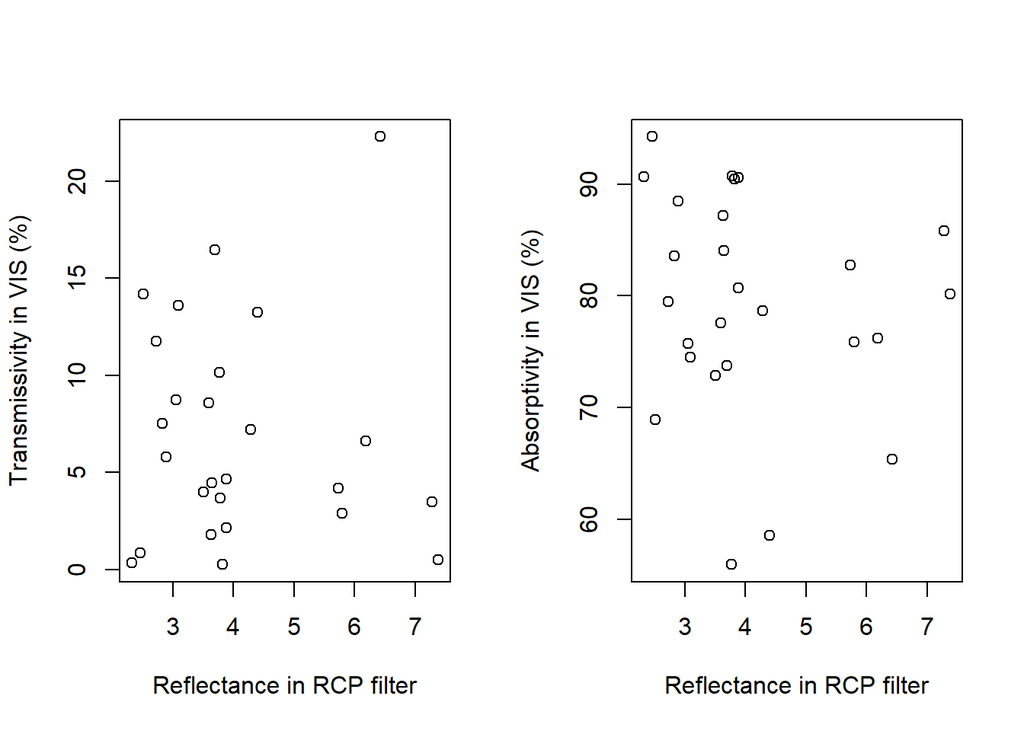

```r
par(mfrow=c(1,2))
plot(RHandTra2$Pol, RHandTra2$VIS,
     ylab=("Transmissivity in VIS (%)"),
     xlab = ("Reflectance in RCP filter"))
plot(RHandAbs2$Pol, RHandAbs2$VIS,
     ylab=("Absorptivity in VIS (%)"),
     xlab = ("Reflectance in RCP filter"))
```

# Mechanisms

We tested the correlations between optical properties, i.e. reflectivity and absorptivity, and polarisation in different subsets of species since these correlations may depend on the underlaying mechanisms.

## Subsets

Subset no underlay:

```r
# reflectivity
NoUnderlayRefl <-
  PolRefl %>%
  dplyr::filter(phylogeny_name != "Paraschizognathus_ocularis" &
    phylogeny_name != "Paraschizognathus_prasinus" &
    phylogeny_name != "Paraschizognathus_olivaceous" &
    phylogeny_name != "Anoplognathus_prasinus" &
    phylogeny_name != "Xylonichus_sp")

# absorptivity
NoUnderlayAbs <-
  PolAbs %>%
  dplyr::filter(phylogeny_name != "Paraschizognathus_ocularis" &
    phylogeny_name != "Paraschizognathus_prasinus" &
    phylogeny_name != "Paraschizognathus_olivaceous" &
    phylogeny_name != "Anoplognathus_prasinus" &
    phylogeny_name != "Xylonichus_sp")
```

Subset no special cases:

```r
# reflectivity
NoSpecialCasesRefl <-
  PolRefl %>%
  dplyr::filter(phylogeny_name != "Paraschizognathus_ocularis" &
    phylogeny_name != "Paraschizognathus_prasinus" &
    phylogeny_name != "Paraschizognathus_olivaceous" &
    phylogeny_name != "Anoplognathus_prasinus" &
    phylogeny_name != "Xylonichus_sp" &
    phylogeny_name != "Epichrysus_lamprimoides" &
    phylogeny_name != "Anoplostethus_laetus" &
    phylogeny_name != "Anoplostethus_opalinus" &
    phylogeny_name != "Anoplostethus_roseus" &
    phylogeny_name != "Anoplognathus_parvulus" &
    phylogeny_name != "Anoplognathus_aureus")

# absorptivity
NoSpecialCasesAbs <-
  PolAbs %>%
  dplyr::filter(phylogeny_name != "Paraschizognathus_ocularis" &
    phylogeny_name != "Paraschizognathus_prasinus" &
    phylogeny_name != "Paraschizognathus_olivaceous" &
    phylogeny_name != "Anoplognathus_prasinus" &
    phylogeny_name != "Xylonichus_sp" &
    phylogeny_name != "Epichrysus_lamprimoides" &
    phylogeny_name != "Anoplostethus_laetus" &
    phylogeny_name != "Anoplostethus_opalinus" &
    phylogeny_name != "Anoplostethus_roseus" &
    phylogeny_name != "Anoplognathus_parvulus" &
    phylogeny_name != "Anoplognathus_aureus")
```

Subset no chiral composites:

```r
# reflectivity
NoCCRefl <-
  PolRefl %>%
  dplyr::filter(phylogeny_name != "Epichrysus_lamprimoides" &
    phylogeny_name != "Anoplostethus_laetus" &
    phylogeny_name != "Anoplostethus_opalinus" &
    phylogeny_name != "Anoplostethus_roseus" &
    phylogeny_name != "Anoplognathus_parvulus" &
    phylogeny_name != "Anoplognathus_aureus")

# absorptivity
NoCCAbs <-
  PolAbs %>%
  dplyr::filter(phylogeny_name != "Epichrysus_lamprimoides" &
    phylogeny_name != "Anoplostethus_laetus" &
    phylogeny_name != "Anoplostethus_opalinus" &
    phylogeny_name != "Anoplostethus_roseus" &
    phylogeny_name != "Anoplognathus_parvulus" &
    phylogeny_name != "Anoplognathus_aureus")
```

## Reflectivity

### VIS

**All species**

```r
cor.test(PolRefl$VIS, PolRefl$Pol) # by spp
```

```
##
##  Pearson's product-moment correlation
##
## data:  PolRefl$VIS and PolRefl$Pol
## t = 1.5434, df = 45, p-value = 0.1297
## alternative hypothesis: true correlation is not equal to 0
## 95 percent confidence interval:
##  -0.06728212  0.48044869
## sample estimates:
##       cor
## 0.2242168
```

**No underlay**

```r
cor.test(NoUnderlayRefl$VIS, NoUnderlayRefl$Pol) # by spp
```

```
##
##  Pearson's product-moment correlation
##
## data:  NoUnderlayRefl$VIS and NoUnderlayRefl$Pol
## t = 1.3748, df = 40, p-value = 0.1768
## alternative hypothesis: true correlation is not equal to 0
## 95 percent confidence interval:
##  -0.09782853  0.48503581
## sample estimates:
##       cor
## 0.2124187
```

**No special cases**

```r
cor.test(NoSpecialCasesRefl$VIS, NoSpecialCasesRefl$Pol) # by spp
```

```
##
##  Pearson's product-moment correlation
##
## data:  NoSpecialCasesRefl$VIS and NoSpecialCasesRefl$Pol
## t = -1.5685, df = 34, p-value = 0.126
## alternative hypothesis: true correlation is not equal to 0
## 95 percent confidence interval:
##  -0.54203774  0.07519306
## sample estimates:
##        cor
## -0.2597597
```

**No chiral composites**

```r
cor.test(NoCCRefl$VIS, NoCCRefl$Pol) # by spp
```

```
##
##  Pearson's product-moment correlation
##
## data:  NoCCRefl$VIS and NoCCRefl$Pol
## t = -1.4969, df = 39, p-value = 0.1425
## alternative hypothesis: true correlation is not equal to 0
## 95 percent confidence interval:
##  -0.50456471  0.08031186
## sample estimates:
##       cor
## -0.233098
```

### NIR

**All species**

```r
cor.test(PolRefl$NIR, PolRefl$Pol) # by spp
```

```
##
##  Pearson's product-moment correlation
##
## data:  PolRefl$NIR and PolRefl$Pol
## t = -1.7419, df = 45, p-value = 0.08836
## alternative hypothesis: true correlation is not equal to 0
## 95 percent confidence interval:
##  -0.50225033  0.03862105
## sample estimates:
##        cor
## -0.2513332
```

**No underlay**

```r
cor.test(NoUnderlayRefl$NIR, NoUnderlayRefl$Pol) # by spp
```

```
##
##  Pearson's product-moment correlation
##
## data:  NoUnderlayRefl$NIR and NoUnderlayRefl$Pol
## t = -0.98424, df = 40, p-value = 0.3309
## alternative hypothesis: true correlation is not equal to 0
## 95 percent confidence interval:
##  -0.4372662  0.1575225
## sample estimates:
##        cor
## -0.1537708
```

**No special cases**

```r
cor.test(NoSpecialCasesRefl$NIR, NoSpecialCasesRefl$Pol) # by spp
```

```
##
##  Pearson's product-moment correlation
##
## data:  NoSpecialCasesRefl$NIR and NoSpecialCasesRefl$Pol
## t = -3.4904, df = 34, p-value = 0.001356
## alternative hypothesis: true correlation is not equal to 0
## 95 percent confidence interval:
##  -0.7205635 -0.2226514
## sample estimates:
##        cor
## -0.5136167
```

**No chiral composites**

```r
cor.test(NoCCRefl$NIR, NoCCRefl$Pol) # by spp
```

```
##
##  Pearson's product-moment correlation
##
## data:  NoCCRefl$NIR and NoCCRefl$Pol
## t = -3.7868, df = 39, p-value = 0.0005151
## alternative hypothesis: true correlation is not equal to 0
## 95 percent confidence interval:
##  -0.7124920 -0.2508605
## sample estimates:
##        cor
## -0.5184949
```

### FRS

**All species**

```r
cor.test(PolRefl$FRS, PolRefl$Pol) # by spp
```

```
##
##  Pearson's product-moment correlation
##
## data:  PolRefl$FRS and PolRefl$Pol
## t = -4.2698, df = 45, p-value = 0.00009974
## alternative hypothesis: true correlation is not equal to 0
## 95 percent confidence interval:
##  -0.7140250 -0.2953307
## sample estimates:
##        cor
## -0.5369585
```

**No underlay**

```r
cor.test(NoUnderlayRefl$FRS, NoUnderlayRefl$Pol) # by spp
```

```
##
##  Pearson's product-moment correlation
##
## data:  NoUnderlayRefl$FRS and NoUnderlayRefl$Pol
## t = -4.2365, df = 40, p-value = 0.0001296
## alternative hypothesis: true correlation is not equal to 0
## 95 percent confidence interval:
##  -0.7359742 -0.3040243
## sample estimates:
##        cor
## -0.5565308
```

**No special cases**

```r
cor.test(NoSpecialCasesRefl$FRS, NoSpecialCasesRefl$Pol) # by spp
```

```
##
##  Pearson's product-moment correlation
##
## data:  NoSpecialCasesRefl$FRS and NoSpecialCasesRefl$Pol
## t = -4.0927, df = 34, p-value = 0.0002481
## alternative hypothesis: true correlation is not equal to 0
## 95 percent confidence interval:
##  -0.7596570 -0.3031927
## sample estimates:
##        cor
## -0.5745024
```

**No chiral composites**

```r
cor.test(NoCCRefl$FRS, NoCCRefl$Pol) # by spp
```

```
##
##  Pearson's product-moment correlation
##
## data:  NoCCRefl$FRS and NoCCRefl$Pol
## t = -3.8721, df = 39, p-value = 0.0004006
## alternative hypothesis: true correlation is not equal to 0
## 95 percent confidence interval:
##  -0.7181806 -0.2617452
## sample estimates:
##        cor
## -0.5269616
```

## Absorptivity

### VIS

**All species**

```r
cor.test(PolAbs$VIS, PolAbs$Pol) # by spp
```

```
##
##  Pearson's product-moment correlation
##
## data:  PolAbs$VIS and PolAbs$Pol
## t = 0.041288, df = 24, p-value = 0.9674
## alternative hypothesis: true correlation is not equal to 0
## 95 percent confidence interval:
##  -0.3801654  0.3944917
## sample estimates:
##         cor
## 0.008427517
```

**No underlay**

```r
cor.test(NoUnderlayAbs$VIS, NoUnderlayAbs$Pol) # by spp
```

```
##
##  Pearson's product-moment correlation
##
## data:  NoUnderlayAbs$VIS and NoUnderlayAbs$Pol
## t = -0.012444, df = 19, p-value = 0.9902
## alternative hypothesis: true correlation is not equal to 0
## 95 percent confidence interval:
##  -0.4340068  0.4293611
## sample estimates:
##          cor
## -0.002854879
```

**No special cases**

```r
cor.test(NoSpecialCasesAbs$VIS, NoSpecialCasesAbs$Pol) # by spp
```

```
##
##  Pearson's product-moment correlation
##
## data:  NoSpecialCasesAbs$VIS and NoSpecialCasesAbs$Pol
## t = 2.8367, df = 14, p-value = 0.01319
## alternative hypothesis: true correlation is not equal to 0
## 95 percent confidence interval:
##  0.1547983 0.8463786
## sample estimates:
##       cor
## 0.6041449
```

**No chiral composites**

```r
cor.test(NoCCAbs$VIS, NoCCAbs$Pol) # by spp
```

```
##
##  Pearson's product-moment correlation
##
## data:  NoCCAbs$VIS and NoCCAbs$Pol
## t = 3.2942, df = 19, p-value = 0.003815
## alternative hypothesis: true correlation is not equal to 0
## 95 percent confidence interval:
##  0.2314862 0.8209405
## sample estimates:
##       cor
## 0.6029232
```

### NIR

**All species**

```r
cor.test(PolAbs$NIR, PolAbs$Pol) # by spp
```

```
##
##  Pearson's product-moment correlation
##
## data:  PolAbs$NIR and PolAbs$Pol
## t = 1.0748, df = 24, p-value = 0.2932
## alternative hypothesis: true correlation is not equal to 0
## 95 percent confidence interval:
##  -0.1887276  0.5555297
## sample estimates:
##       cor
## 0.2142898
```

**No underlay**

```r
cor.test(NoUnderlayAbs$NIR, NoUnderlayAbs$Pol) # by spp
```

```
##
##  Pearson's product-moment correlation
##
## data:  NoUnderlayAbs$NIR and NoUnderlayAbs$Pol
## t = 0.33542, df = 19, p-value = 0.741
## alternative hypothesis: true correlation is not equal to 0
## 95 percent confidence interval:
##  -0.3671231  0.4921109
## sample estimates:
##        cor
## 0.07672295
```

**No special cases**

```r
cor.test(NoSpecialCasesAbs$NIR, NoSpecialCasesAbs$Pol) # by spp
```

```
##
##  Pearson's product-moment correlation
##
## data:  NoSpecialCasesAbs$NIR and NoSpecialCasesAbs$Pol
## t = 2.6934, df = 14, p-value = 0.01748
## alternative hypothesis: true correlation is not equal to 0
## 95 percent confidence interval:
##  0.1245892 0.8374076
## sample estimates:
##       cor
## 0.5842138
```

**No chiral composites**

```r
cor.test(NoCCAbs$NIR, NoCCAbs$Pol) # by spp
```

```
##
##  Pearson's product-moment correlation
##
## data:  NoCCAbs$NIR and NoCCAbs$Pol
## t = 3.6547, df = 19, p-value = 0.001685
## alternative hypothesis: true correlation is not equal to 0
## 95 percent confidence interval:
##  0.2917107 0.8409388
## sample estimates:
##       cor
## 0.6424902
```

### FRS

**All species**

```r
cor.test(PolAbs$FRS, PolAbs$Pol) # by spp
```

```
##
##  Pearson's product-moment correlation
##
## data:  PolAbs$FRS and PolAbs$Pol
## t = 2.2597, df = 24, p-value = 0.03319
## alternative hypothesis: true correlation is not equal to 0
## 95 percent confidence interval:
##  0.03759808 0.69366079
## sample estimates:
##     cor
## 0.41885
```

**No underlay**

```r
cor.test(NoUnderlayAbs$FRS, NoUnderlayAbs$Pol) # by spp
```

```
##
##  Pearson's product-moment correlation
##
## data:  NoUnderlayAbs$FRS and NoUnderlayAbs$Pol
## t = 0.93021, df = 19, p-value = 0.3639
## alternative hypothesis: true correlation is not equal to 0
## 95 percent confidence interval:
##  -0.2450606  0.5874641
## sample estimates:
##      cor
## 0.208705
```

**No special cases**

```r
cor.test(NoSpecialCasesAbs$FRS, NoSpecialCasesAbs$Pol) # by spp
```

```
##
##  Pearson's product-moment correlation
##
## data:  NoSpecialCasesAbs$FRS and NoSpecialCasesAbs$Pol
## t = 0.68241, df = 14, p-value = 0.5061
## alternative hypothesis: true correlation is not equal to 0
## 95 percent confidence interval:
##  -0.3471587  0.6199864
## sample estimates:
##       cor
## 0.1794233
```

**No chiral composites**

```r
cor.test(NoCCAbs$FRS, NoCCAbs$Pol) # by spp
```

```
##
##  Pearson's product-moment correlation
##
## data:  NoCCAbs$FRS and NoCCAbs$Pol
## t = 1.7531, df = 19, p-value = 0.0957
## alternative hypothesis: true correlation is not equal to 0
## 95 percent confidence interval:
##  -0.06978245  0.69317408
## sample estimates:
##      cor
## 0.373145
```

# Plots

## Degree of polarisation

```r
ReflByInd <- read.csv(here::here("Data/FromCode/ConsolidatedReflectivityInd.csv"))[-1]

AbsByInd0 <- read.csv(here::here("Data/FromCode/ConsolidatedAbsorptivityInd.csv"))[-1]

AbsByInd0$A_Res <- residuals ( lm (AbsByInd0$A_NIR~AbsByInd0$A_VIS))

# Mean and sd per species Absorptivity
AbsByInd <-
AbsByInd0 %>%
  dplyr::mutate("spp" = substr(ind, 1, 4)) %>%
  dplyr::select(spp, A_VIS, A_NIR, A_Res) %>%
  dplyr::group_by(spp) %>%
  dplyr::summarise(
    meanVISA = mean(A_VIS),
    meanNIRA = mean(A_NIR),
    meanResA = mean(A_Res),
    sdVISA = sd(A_VIS),
    sdNIRA = sd(A_NIR),
    sdResA = sd(A_Res),
      )
AbsByInd <- as.data.frame(AbsByInd)

#mean and sd of transmittance per species

TraByInd <-
AbsByInd0 %>%
  dplyr::mutate("spp" = substr(ind, 1, 4)) %>%
  dplyr::select(spp, T_VIS) %>%
  dplyr::group_by(spp) %>%
  dplyr::summarise(
    meanVIST = mean(T_VIS),
    sdVIST = sd(T_VIS)
      )
TraByInd <- as.data.frame(TraByInd)

# Mean and sd per species Reflectivity including pol
ToPlotPolRefl <-
  merge(ReflByInd[,c(1,3,4,5)], PolByInd, by = "ind") %>%
  dplyr::select(-phylogeny_name) %>%
  dplyr::group_by(spp) %>%
  dplyr::summarise(
    meanVIS = mean(R_VIS),
    meanNIR = mean(R_NIR),
    meanRes = mean(Res),
    meanPol = mean(Polarization),
    sdVIS = sd(R_VIS),
    sdNIR = sd(R_NIR),
    sdRes = sd(Res),
    sdPol = sd(Polarization)
  )

ToPlotPolRefl <- as.data.frame(ToPlotPolRefl)
rownames(ToPlotPolRefl) <- ToPlotPolRefl$spp

ToPlotPolAbs <- merge(
  ToPlotPolRefl[,c("spp", "meanPol", "sdPol")], AbsByInd)
rownames(ToPlotPolAbs) <- ToPlotPolAbs$spp

ToPlotPolTra <- merge(
  ToPlotPolRefl[,c("spp", "meanPol", "sdPol")], TraByInd)
rownames(ToPlotPolTra) <- ToPlotPolTra$spp
```

Subset for plotting

```r
UnderlayRefl <- ToPlotPolRefl %>%
  dplyr::filter(spp == "xyls" |
                spp == "xyle" |
                spp == "pczo" |
                spp == "pczp" |
                spp == "pczv" |
                spp == "prsi")
UnderlayAbs <- ToPlotPolAbs %>%
  dplyr::filter(spp == "xyls" |
                spp == "xyle" |
                spp == "pczo" |
                spp == "pczp" |
                spp == "pczv" |
                spp == "prsi")

NoUnderlayRefl <- ToPlotPolRefl %>%
  dplyr::filter(spp != "xyls" |
                spp != "xyle" |
                spp != "pczo" |
                spp != "pczp" |
                spp != "pczv" |
                spp != "prsi")
NoUnderlayAbs <- ToPlotPolAbs %>%
  dplyr::filter(spp != "xyls" |
                spp != "xyle" |
                spp != "pczo" |
                spp != "pczp" |
                spp != "pczv" |
                spp != "prsi")
```

Predictions from PGLS for the NIR reflectivity and absorptivity

```r
## set values for predictors:
PolDeg <- seq(range(ToPlotPolRefl$meanPol)[1],
             range(ToPlotPolRefl$meanPol)[2],0.01) # A range of Pol values

new1<-data.frame("Pol" = PolDeg) # data frame

RefDeg<-predict(pglsPDFRS, newdata = new1,
              type = "response") # Expected reflectivity
trend1<-data.frame(PolDeg,RefDeg) # Pol values and expected reflectivity joint

AbsDeg<-predict(pglsPDFRSAbs, newdata = new1,
              type = "response") # Expected absorptivity
trend2<-data.frame(PolDeg,AbsDeg) # Pol values and expected reflectivity joint
```

```r
## set values for predictors:
PolDeg <- seq(range(ToPlotPolRefl$meanPol)[1],
             range(ToPlotPolRefl$meanPol)[2],0.01) # A range of Pol values

new1<-data.frame("Pol" = PolDeg) # data frame

RefDeg<-predict(pglsPDFRS, newdata = new1,
              type = "response") # Expected reflectivity

trend1<-data.frame(PolDeg,RefDeg) # Pol values and expected reflectivity joint
```

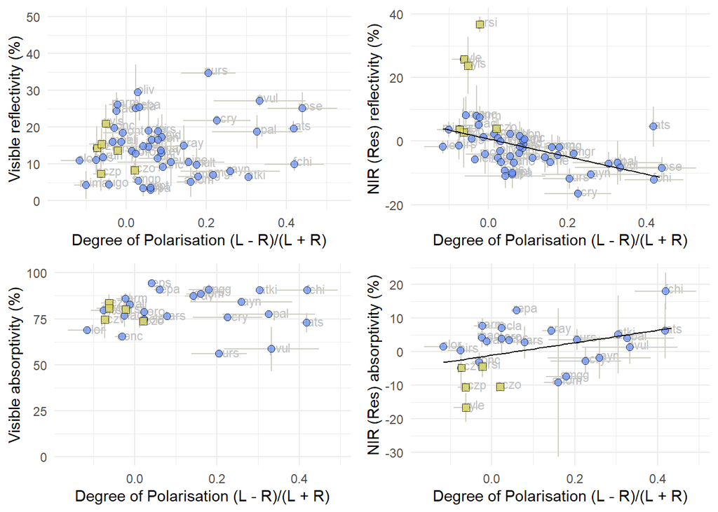

```r
NudgeXVal = 0.02
NudgeYVal = 0.9

PVRPlot <- ggplot(data = ToPlotPolRefl, aes(x = meanPol, y = meanVIS),
             size = 2.2, alpha = 0.6) +
  geom_text(
    label=rownames(ToPlotPolRefl),
    nudge_x = NudgeXVal, nudge_y = NudgeYVal,
    col="gray", size=3
  ) +
  # error bars
  geom_errorbar(aes(
                ymin = meanVIS - sdVIS,
                ymax = meanVIS + sdVIS),
  col = "#cecec2"
  ) +
  geom_errorbarh(aes(
    xmin = meanPol - sdPol,
    xmax = meanPol + sdPol
  ),
  col = "#cecec2"
  ) +
  geom_point(data = NoUnderlayRefl, size = 2.2, pch = 21, fill = "#648fff", color = "black", alpha = 0.7) +
  geom_point(data = UnderlayRefl, size = 2.4, pch = 22, fill = "#F7E949", color = "black", alpha = 0.7) +
  theme_minimal() +
  theme(legend.position = "none") +
  xlab("Degree of Polarisation (L - R)/(L + R)")+
  ylab("Visible reflectivity (%)") +
  ylim(0, 50)

PNRPlot <- ggplot(data = ToPlotPolRefl, aes(x = meanPol, y = meanRes),
             size = 2.2, alpha = 0.6) +
  geom_text(
    label=rownames(ToPlotPolRefl),
    nudge_x = NudgeXVal, nudge_y = NudgeYVal,
    col="gray", size=3
  ) +
  # error bars
  geom_errorbar(aes(
                ymin = meanRes - sdRes,
                ymax = meanRes + sdRes),
  col = "#cecec2"
  ) +
  geom_errorbarh(aes(
    xmin = meanPol - sdPol,
    xmax = meanPol + sdPol
  ),
  col = "#cecec2"
  ) +
  geom_point(data = NoUnderlayRefl, size = 2.2, pch = 21, fill = "#648fff", color = "black", alpha = 0.7) +
  geom_point(data = UnderlayRefl, size = 2.4, pch = 22, fill = "#F7E949", color = "black", alpha = 0.7) +
  geom_line(data=trend1, aes(x= PolDeg, y= RefDeg), color = "black") +
  theme_minimal() +
  theme(legend.position = "none") +
  xlab("Degree of Polarisation (L - R)/(L + R)")+
  ylab("NIR (Res) reflectivity (%)")


PVAPlot <- ggplot(data = ToPlotPolAbs, aes(x = meanPol, y = meanVISA),
             size = 2.2, alpha = 0.6) +
  geom_text(
    label=rownames(ToPlotPolAbs),
    nudge_x = NudgeXVal, nudge_y = NudgeYVal,
    col="gray", size=3
  ) +
  # error bars
  geom_errorbar(aes(
                ymin = meanVISA - sdVISA,
                ymax = meanVISA + sdVISA),
  col = "#cecec2"
  ) +
  geom_errorbarh(aes(
    xmin = meanPol - sdPol,
    xmax = meanPol + sdPol
  ),
  col = "#cecec2"
  ) +
  geom_point(data = NoUnderlayAbs, size = 2.2, pch = 21, fill = "#648fff", color = "black", alpha = 0.7) +
  geom_point(data = UnderlayAbs, size = 2.4, pch = 22, fill = "#F7E949", color = "black", alpha = 0.7) +
  theme_minimal() +
  theme(legend.position = "none") +
  xlab("Degree of Polarisation (L - R)/(L + R)")+
  ylab("Visible absorptivity (%)") +
  ylim(0, 100)

PNAPlot <- ggplot(data = ToPlotPolAbs, aes(x = meanPol, y = meanResA),
             size = 2.2, alpha = 0.6) +
  geom_text(
    label=rownames(ToPlotPolAbs),
    nudge_x = NudgeXVal, nudge_y = NudgeYVal,
    col="gray", size=3
  ) +
  # error bars
  geom_errorbar(aes(
                ymin = meanResA - sdResA,
                ymax = meanResA + sdResA),
  col = "#cecec2"
  ) +
  geom_errorbarh(aes(
    xmin = meanPol - sdPol,
    xmax = meanPol + sdPol
  ),
  col = "#cecec2"
  ) +
  geom_point(data = NoUnderlayAbs, size = 2.2, pch = 21, fill = "#648fff", color = "black", alpha = 0.7) +
  geom_point(data = UnderlayAbs, size = 2.4, pch = 22, fill = "#F7E949", color = "black", alpha = 0.7) +
  geom_line(data=trend2, aes(x= PolDeg, y= AbsDeg), color = "black") +
  theme_minimal() +
  theme(legend.position = "none") +
  xlab("Degree of Polarisation (L - R)/(L + R)")+
  ylab("NIR (Res) absorptivity (%)")


grid.arrange(PVRPlot, PNRPlot, PVAPlot, PNAPlot, nrow = 2)
```

```r
PNRPlot
```

[output not shown]

## Right handed polarisation

Setting up data frames by individual for plots

```r
# Import equalised values for right handed polarisation
RHand0I<-read.csv(here::here("Data/FromCode/PolarzElytra_LERGBValues.csv"))[-1]%>%
  dplyr::filter(Type == "RCP") %>%
  dplyr::select(-Type) %>%
  dplyr::rename("RHPol" = RGB_ave)

# Load degree of polarisation per individual
PolDeg0I <- read.csv(here::here("Data/FromCode/PolarzElytraByInd.csv"))[-1] %>%
  dplyr::select(ind, Polarization)

# Merge RCP with degree of polarisation
RHandWPolDeg <- merge(RHand0I, PolDeg0I)

# Join them with the phylogeny names
SppNamesI<-read.csv(here::here("Data/9_CodesAndSpecies.csv")) %>%
  dplyr::rename("ind" = Ind)
RHandWPolDegByInd <- merge(RHandWPolDeg, SppNamesI)

# Add 4-letter spp code
RHandWPolDegByInd <-
  RHandWPolDegByInd %>%
  dplyr::mutate(spp = substr(ind, 1, 4))

# Combine with visible reflectivity
RHandPolDegReflByInd <- merge(RHandWPolDegByInd, ReflByInd) %>%
  dplyr::select(-R_ALL, -R_NIR, -Res, -size)
```

And re order them to plot

```r
ToPlotRHPolRefl <-
  RHandPolDegReflByInd %>%
  dplyr::select(-phylogeny_name) %>%
  dplyr::group_by(spp) %>%
  dplyr::summarise(
    meanVIS = mean(R_VIS),
    meanRHPol = mean(RHPol),
    meanPol = mean(Polarization),
    sdVIS = sd(R_VIS),
    sdRHPol = sd(RHPol),
    sdPol = sd(Polarization)
  )

ToPlotRHPolRefl <- as.data.frame(ToPlotRHPolRefl)
rownames(ToPlotRHPolRefl) <- ToPlotRHPolRefl$spp
```

Predictions from PGLS for the VIS reflectivity

```r
## set values for predictors:
RHPolSeq <- seq(range(ToPlotRHPolRefl$meanRHPol)[1],
             range(ToPlotRHPolRefl$meanRHPol)[2],0.01) # A range of Pol values

new1RH<-data.frame("Pol" = RHPolSeq) # data frame

RefRHPolPred <- predict(pglsPDVISRH, newdata = new1RH,
              type = "response") # Expected reflectivity
trend1RH<-data.frame(RHPolSeq, RefRHPolPred) # Pol values and expected reflectivity joint
```

Plots

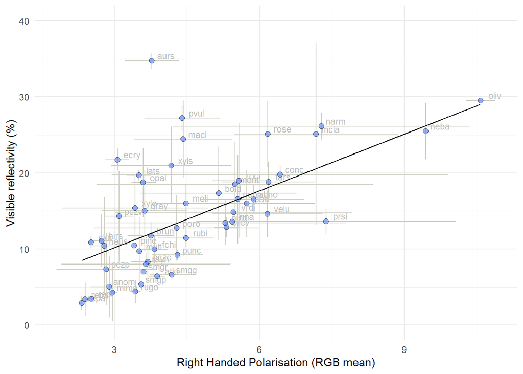

```r
NudgeXVal = 0.3
NudgeYVal = 0.7


RCPVRPlot <- ggplot(data = ToPlotRHPolRefl, aes(x = meanRHPol, y = meanVIS),
             size = 2.2, alpha = 0.6) +
  geom_text(
    label=rownames(ToPlotRHPolRefl),
    nudge_x = NudgeXVal, nudge_y = NudgeYVal,
    col="gray", size=3
  ) +
  # error bars
  geom_errorbar(aes(
                ymin = meanVIS - sdVIS,
                ymax = meanVIS + sdVIS),
  col = "#cecec2"
  ) +
  geom_errorbarh(aes(
    xmin = meanRHPol - sdRHPol,
    xmax = meanRHPol + sdRHPol
  ),
  col = "#cecec2"
  ) +
  geom_point(data = ToPlotRHPolRefl, size = 2.2, pch = 21,
             fill = "#648fff", color = "black", alpha = 0.7) +
  geom_line(data=trend1RH, aes(x= RHPolSeq, y= RefRHPolPred), color = "black") +
  theme_minimal() +
  theme(legend.position = "none") +
  xlab("Right Handed Polarisation (RGB mean)")+
  ylab("Visible reflectivity (%)") +
  ylim(0, 40)


RCPVRPlot
```